# Advanced Bioinformatics 2026 Assignment

K24121615

2026-04-04

## Task 3.1

#Using the ‘:’ operator to generate a sequence from 5 to 55 and ‘sum()’ to all them all together.

```r
sum (5:55)
```

```
## [1] 1530
```

## Task 3.2

#Generating a function called ‘sumfun’ that calculates the sum of all integers between 5 and n.

```r
sumfun <- function(n){
return(sum(5:n))
}
sumfun (10)
```

```
## [1] 45
```

```r
sumfun (20)
```

```
## [1] 200
```

```r
sumfun (100)
```

```
## [1] 5040
```

## Task 3.3

#Using a for loop to calculate the first 12 Fibonacci numbers. The sequence starts with two 1s and each value is the sum of the 2 preceding values.

```r
fib <- numeric(12)
fib[1] <- 1
fib[2] <- 1
for (i in 3:12) {
fib[i] <- fib[i-1] + fib[i-2]
}
print(fib)
```

```
##  [1]   1   1   2   3   5   8  13  21  34  55  89 144
```

## Task 3.4

#Using ggplot2 to plot miles per gallon by nember of gears from the mtcars dataset, gear is converted to a afcttor so ggplot treats it as categorical.

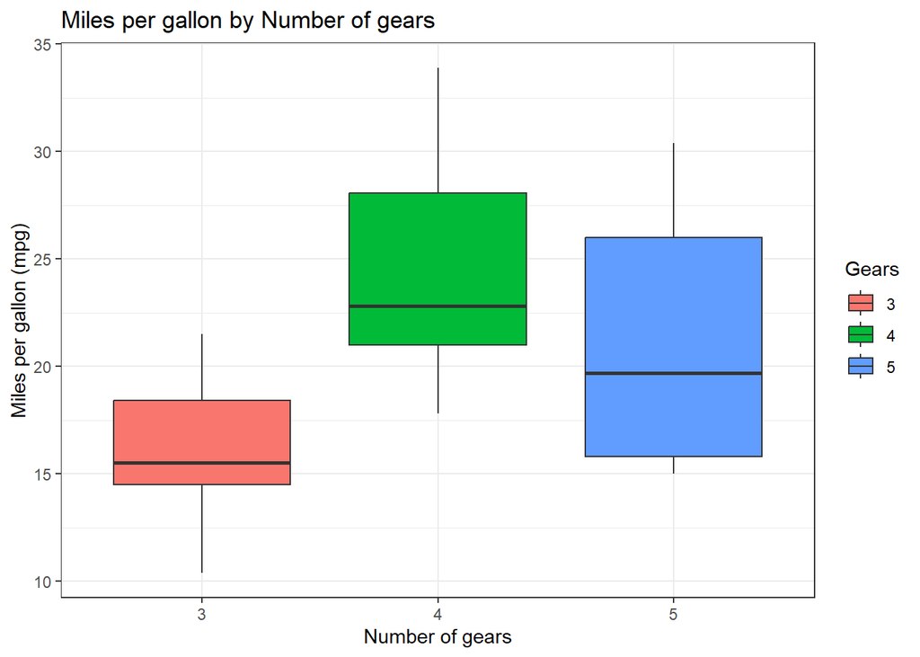

```r
library(ggplot2)
ggplot(mtcars, aes(x = factor(gear), y = mpg, fill = factor(gear))) + geom_boxplot() +
labs(
title = "Miles per gallon by Number of gears",
x = "Number of gears",
y = "Miles per gallon (mpg)",
fill = "Gears"
) +
theme_bw()
```

## Task 3.5

#Fitting a linear model to examine the relationship between speed and stopping distance in the cars dataset. summary() extracts the coefficients and their standard error.

```r
model <- lm(dist ~ speed, data = cars)
summary(model)
```

```
##
## Call:
## lm(formula = dist ~ speed, data = cars)
##
## Residuals:
##     Min      1Q  Median      3Q     Max
## -29.069  -9.525  -2.272   9.215  43.201
##
## Coefficients:
##             Estimate Std. Error t value Pr(>|t|)
## (Intercept) -17.5791     6.7584  -2.601   0.0123 *
## speed         3.9324     0.4155   9.464 1.49e-12 ***
## ---
## Signif. codes:  0 '***' 0.001 '**' 0.01 '*' 0.05 '.' 0.1 ' ' 1
##
## Residual standard error: 15.38 on 48 degrees of freedom
## Multiple R-squared:  0.6511, Adjusted R-squared:  0.6438
## F-statistic: 89.57 on 1 and 48 DF,  p-value: 1.49e-12
```

## Task 3.6

# Plotting the cars data points and the linear regression line from Task 3.5. geom_smooth(method = “lm”) fits and draws the line with a confidence interval.

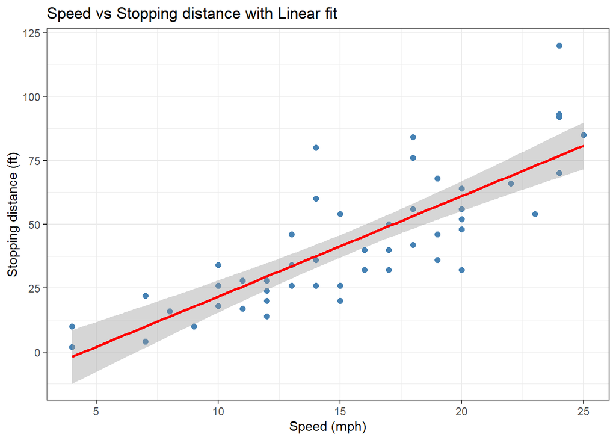

```r
ggplot(cars, aes(x = speed, y = dist)) +
geom_point(colour = "steelblue", size = 2) +
geom_smooth(method = "lm", se = TRUE, colour = "red") +
labs(
title = "Speed vs Stopping distance with Linear fit",
x = "Speed (mph)",
y = "Stopping distance (ft)"
) +
theme_bw()
```

## Task 3.7

# Modelling stopping distance as reaction distance plus braking distance. A linear model with no intercept is fitted using speed and speed-squared as predictors to estimate driver reaction time.

# Create speed-squared variable

```r
cars$speed2 <- cars$speed^2
```

# Fit model with no intercept

```r
model_reaction <- lm(dist ~ 0 + speed + speed2, data = cars)
summary(model_reaction)
```

```
##
## Call:
## lm(formula = dist ~ 0 + speed + speed2, data = cars)
##
## Residuals:
##     Min      1Q  Median      3Q     Max
## -28.836  -9.071  -3.152   4.570  44.986
##
## Coefficients:
##        Estimate Std. Error t value Pr(>|t|)
## speed   1.23903    0.55997   2.213  0.03171 *
## speed2  0.09014    0.02939   3.067  0.00355 **
## ---
## Signif. codes:  0 '***' 0.001 '**' 0.01 '*' 0.05 '.' 0.1 ' ' 1
##
## Residual standard error: 15.02 on 48 degrees of freedom
## Multiple R-squared:  0.9133, Adjusted R-squared:  0.9097
## F-statistic: 252.8 on 2 and 48 DF,  p-value: < 2.2e-16
```

# Convert coefficient to seconds

# 1 mph = 5280/3600 feet per second

# reaction_time (seconds) = coefficient of speed / 1.467

```r
t_r <- coef(model_reaction)["speed"] / (5280/3600)
cat("Estimated reaction time:", round(t_r, 3), "seconds\n")
```

```
## Estimated reaction time: 0.845 seconds
```

# Plot the results

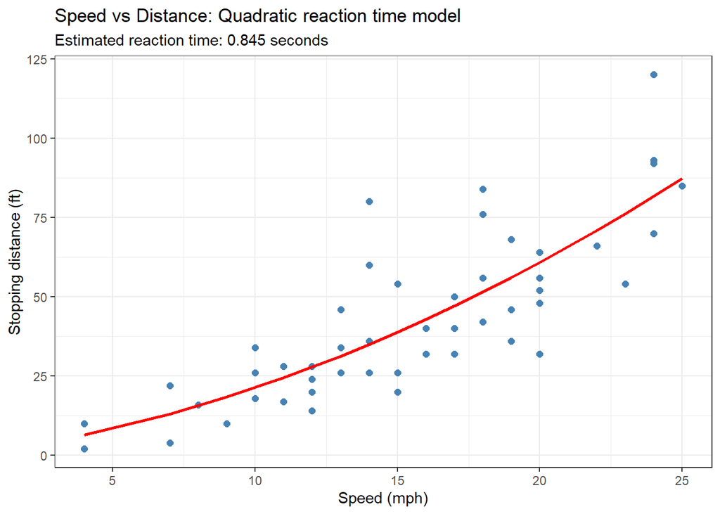

```r
cars$fitted_reaction <- fitted(model_reaction)
ggplot(cars, aes(x = speed)) +
geom_point(aes(y = dist), colour = "steelblue", size = 2) +
geom_line(aes(y = fitted_reaction), colour = "red", linewidth = 1) +
labs(
title = "Speed vs Distance: Quadratic reaction time model",
subtitle = paste("Estimated reaction time:", round(t_r, 3), "seconds"),
x = "Speed (mph)",
y = "Stopping distance (ft)"
) +
theme_bw()
```

## Task 3.8

# Reading in the count matrix and sample metadata files from the tutorial data.

```r
library(DESeq2)
count_data <- read.csv(
"C:/Users/simar/Downloads/LMS_RNAseq_short-master-2023-final/LMS_RNAseq_short-master-2023-final/course/exercises/data/exercise1_counts.csv",
row.names = 1
)
sample_desc <- read.table(
"C:/Users/simar/Downloads/LMS_RNAseq_short-master-2023-final/LMS_RNAseq_short-master-2023-final/course/exercises/data/exercise1_sample_description.info",
header = TRUE,
sep = "\t"
)
head(count_data)
```

```
##           control_FFa1.bam control_FFa2.bam control_FFa3.bam mutant_KOa1.bam
## 497097                  16               16                0              21
## 100503874               20                0                0              64
## 100038431                0                0                2               0
## 19888                   11                0               10             113
## 20671                   14               16                0              40
## 27395                  465              193              596             436
##           mutant_KOa2.bam mutant_KOa3.bam mutant_KOb1.bam mutant_KOb2.bam
## 497097                 16              27              20               0
## 100503874               0               4               5               0
## 100038431               0               8               0               0
## 19888                   0              26              14               6
## 20671                   8              33              33              12
## 27395                 686             572            1378            1901
##           mutant_KOb3.bam
## 497097                  2
## 100503874               2
## 100038431               0
## 19888                  16
## 20671                  24
## 27395                1553
```

```r
head(sample_desc)
```

```
##              filename sample condition batch
## 1    control_FFa1.bam   FFa1       FFa     a
## 2    control_FFa2.bam   FFa2       FFa     b
## 3    control_FFa3.bam   FFa3       FFa     c
## 4 TMC_mutant_KOa1.bam   KOa1       KOa     a
## 5 TMC_mutant_KOa2.bam   KOa2       KOa     b
## 6 TMC_mutant_KOa3.bam   KOa3       KOa     c
```

## Task 3.9

# Creating col_data, a data frame of sample metadata required by DESeq2. Row names must match column names of count_data exactly.

```r
col_data <- data.frame(
condition = sample_desc$condition,
row.names = colnames(count_data)
)
dim(count_data)
```

```
## [1] 26301     9
```

```r
dim(col_data)
```

```
## [1] 9 1
```

```r
all(colnames(count_data) == rownames(col_data))
```

```
## [1] TRUE
```

## Task 3.10

# Constructing the DESeqDataSet object. The design formula ~ condition tells DESeq2 to model expression differences between conditions. Low-count genes are pre-filtered to improve statistical power.

```r
dds <- DESeqDataSetFromMatrix(
countData = count_data,
colData = col_data,
design = ~ condition
)
```

# Remove genes with fewer than 10 total reads.

```r
keep <- rowSums(counts(dds)) >= 10
dds <- dds[keep, ]
dds
```

```
## class: DESeqDataSet
## dim: 23295 9
## metadata(1): version
## assays(1): counts
## rownames(23295): 497097 100503874 ... 21674 100042881
## rowData names(0):
## colnames(9): control_FFa1.bam control_FFa2.bam ... mutant_KOb2.bam
##   mutant_KOb3.bam
## colData names(1): condition
```

## Task 3.11

# Applying rlog and VST transformations to stabilise variance across genes. Both produce approximately normally distributed data suitable for visualisation. blind = TRUE means the design is ignored, appropriate for QC.

```r
rlog_data <- rlog(dds, blind = TRUE)
vst_data <- vst(dds, blind = TRUE)
class(rlog_data)
```

```
## [1] "DESeqTransform"
## attr(,"package")
## [1] "DESeq2"
```

```r
class(vst_data)
```

```
## [1] "DESeqTransform"
## attr(,"package")
## [1] "DESeq2"
```

## Task 3.12

# Drawing heatmaps of the top 40 most highly expressed genes using both transformations. scale = “row” standardises each gene so colour reflects relative change rather than absolute expression.

```r
library(pheatmap)
```

# rlog heatmap

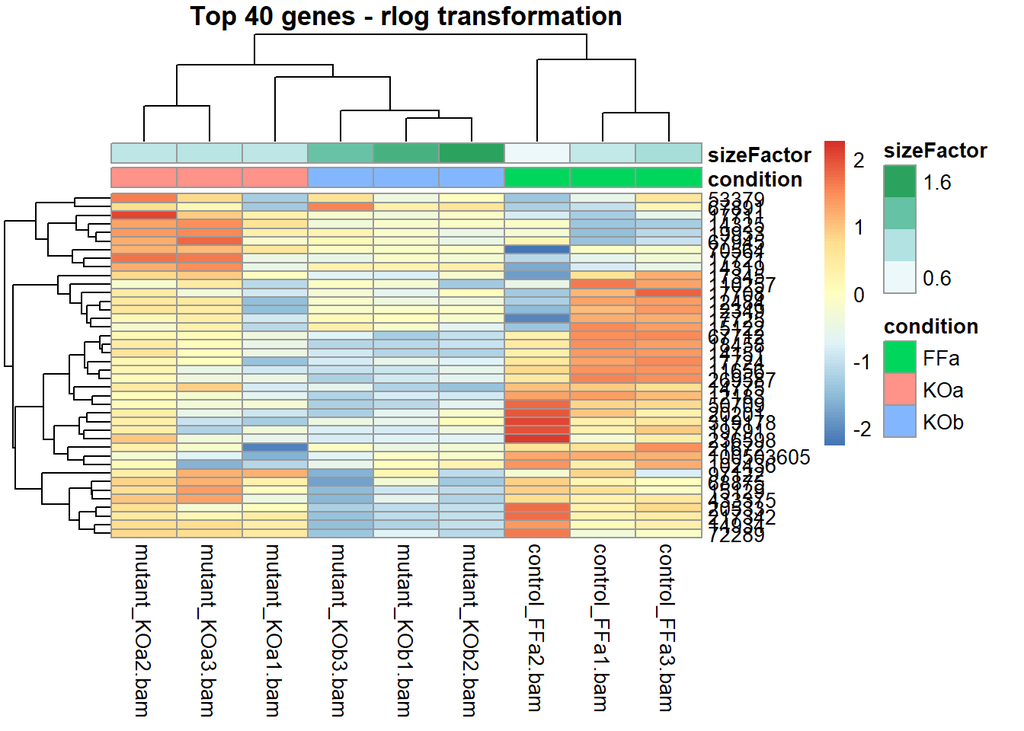

```r
rlog_mat <- assay(rlog_data)
top40_idx<- head(order(rowMeans(rlog_mat), decreasing = TRUE), 40)
pheatmap(
rlog_mat[top40_idx, ],
cluster_rows = TRUE,
cluster_cols = TRUE,
show_rownames = TRUE,
annotation_col = as.data.frame(colData(rlog_data)),
scale = "row",
main = "Top 40 genes - rlog transformation"
)
```

# VST heatmap

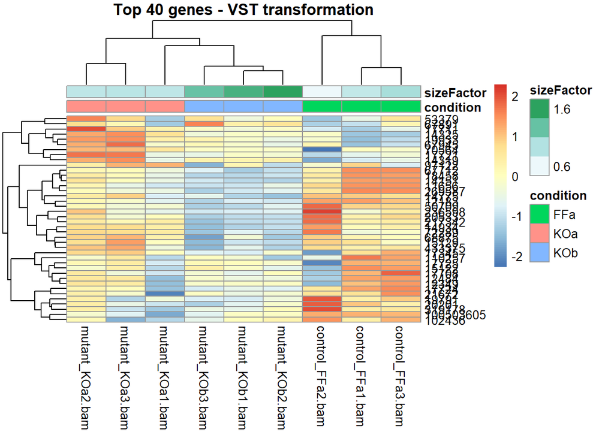

```r
vst_mat <- assay(vst_data)
top40_vst <- head(order(rowMeans(vst_mat), decreasing = TRUE), 40)
pheatmap(
vst_mat[top40_vst, ],
cluster_rows = TRUE,
cluster_cols = TRUE,
show_rownames = TRUE,
annotation_col = as.data.frame(colData(vst_data)),
scale = "row",
main = "Top 40 genes - VST transformation"
)
```

## Task 3.13

# Generating a sample distance matrix to assess overall similarity between samples. Euclidean distances are calculated between all pairs of samples. Samples from the same conditions should cluster togther.

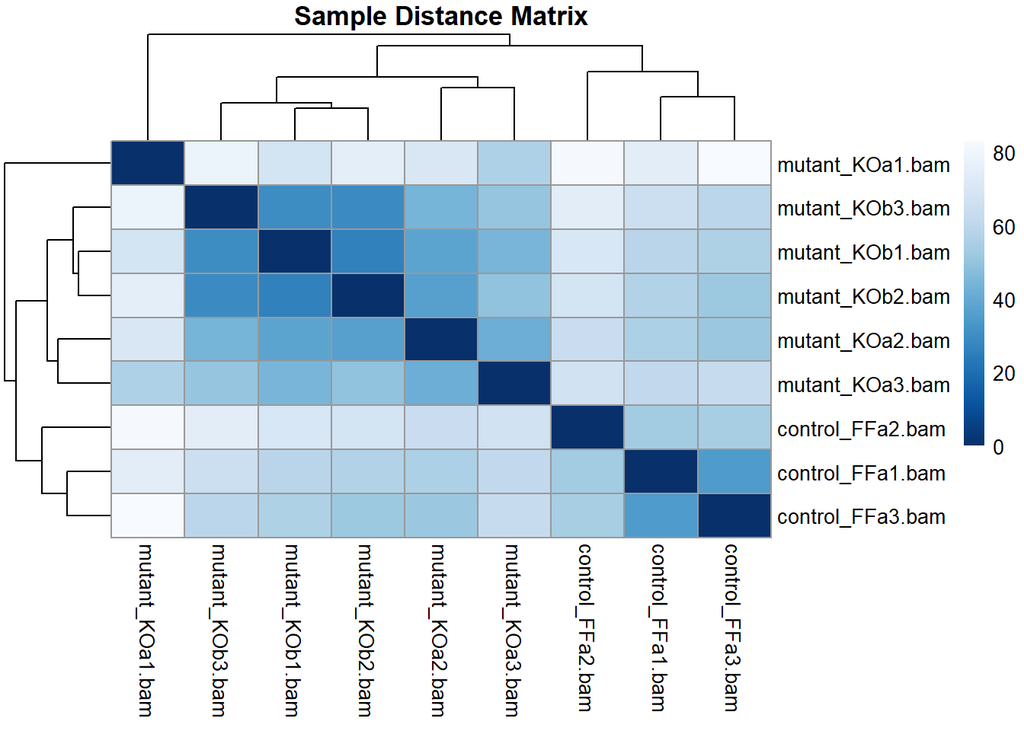

```r
library(RColorBrewer)
sample_dists <- dist(t(assay(rlog_data)))
sdm <- as.matrix(sample_dists)
rownames(sdm) <- colnames(rlog_data)
colnames(sdm) <- colnames(rlog_data)
colours <- colorRampPalette(rev(brewer.pal(9, "Blues")))(255)
pheatmap(
sdm,
clustering_distance_rows = sample_dists,
clustering_distance_cols = sample_dists,
col  = colours,
main = "Sample Distance Matrix"
)
```

## Task 3.14

# Performing PCA on rlog-transformed data using the top 500 most variabe genes. PC1 and PC2 are plotted with the percentage of variance they explain shown on the axis.

```r
pca_rlog <- plotPCA(rlog_data, intgroup = "condition", returnData = TRUE)
```

```
## using ntop=500 top features by variance
```

```r
percentVar_rlog <- round(100 * attr(pca_rlog, "percentVar"))
cat("PC1 explains:", percentVar_rlog[1], "% of variance\n")
```

```
## PC1 explains: 70 % of variance
```

```r
cat("PC2 explains:", percentVar_rlog[2], "% of variance\n")
```

```
## PC2 explains: 13 % of variance
```

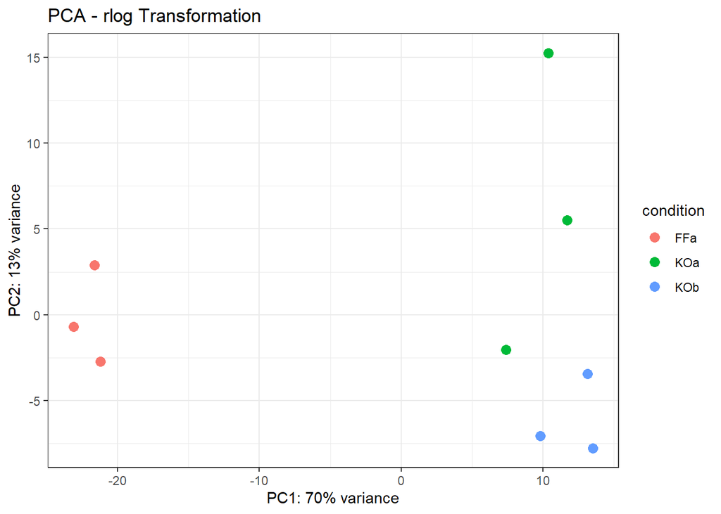

```r
ggplot(pca_rlog, aes(x = PC1, y = PC2, colour = condition)) +
geom_point(size = 3) +
labs(
title = "PCA - rlog Transformation",
x = paste0("PC1: ", percentVar_rlog[1], "% variance"),
y = paste0("PC2: ", percentVar_rlog[2], "% variance")
) +
theme_bw()
```

## Task 3.15

# Repeating PCA using VST-transformed data and comparing with the rlog PCA. Both should show similar clustering. rlog is more robust for small datasets while VST is faster for larger ones.

```r
pca_vst <- plotPCA(vst_data, intgroup = "condition", returnData = TRUE)
```

```
## using ntop=500 top features by variance
```

```r
percentVar_vst <- round(100 * attr(pca_vst, "percentVar"))
cat("VST - PC1 explains:", percentVar_vst[1], "% of variance\n")
```

```
## VST - PC1 explains: 69 % of variance
```

```r
cat("VST - PC2 explains:", percentVar_vst[2], "% of variance\n")
```

```
## VST - PC2 explains: 14 % of variance
```

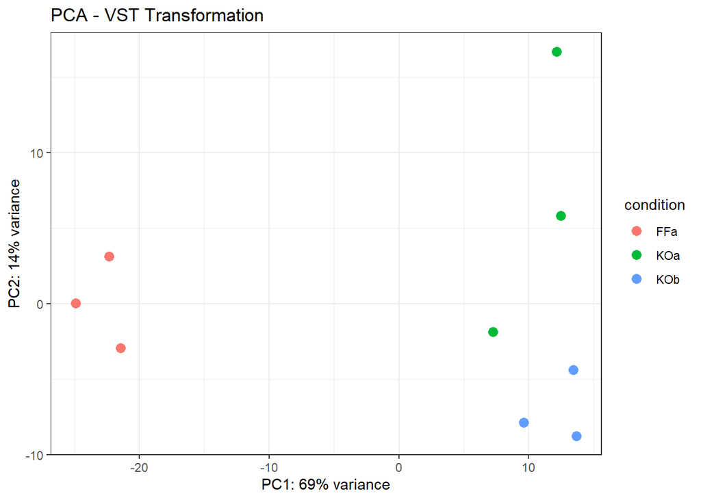

```r
ggplot(pca_vst, aes(x = PC1, y = PC2, colour = condition)) +
geom_point(size = 3) +
labs(
title = "PCA - VST Transformation",
x = paste0("PC1: ", percentVar_vst[1], "% variance"),
y = paste0("PC2: ", percentVar_vst[2], "% variance")
) +
theme_bw()
```